# **Cities In Maryland**

Created by: Jackson Lin, Andy Ni, and Annie Yang

1. Introduction
2. Python Libraries and Tools Used
3. Data Collection
4. Data Processing
5. Exploratory Analysis & Data Visualization
6. Model: Analysis, Hypothesis Testing, & ML
7. Conclusion and Future Insights

## Introduction

Finding the perfect place to live in Maryland can be hard for some people, but we're here to make it easier. Our project helps people that are looking to settle down or move to Maryland by considering important stuff like housing costs, job opportunities, and safety.

## Python Libraries and Tools Used

We will be using Python3 and the following libraries and tools for our project:

- [pandas](https://pandas.pydata.org/): We use pandas for data manipulation and analysis. It provides data structures and tools for reading, cleaning, transforming, and analyzing structured data.
- [numpy](https://numpy.org/): We use numpy for numerical operations. NumPy is a fundamental package for computing in Python, making it easier to deal with large arrays and matrices.
- [matplotlib](https://matplotlib.org/): We use matplotlib for plotting graphs and visualizations. Matplotlib is for creating static, animated, and interactive visualizations in Python. For example graphs in our case.
- [selenium](https://www.selenium.dev/): We use selenium automating web browsers. Selenium is used for web scraping, testing, and automating web applications. It enables interaction with web pages and extraction of data.
- [webdriver-manager](https://pypi.org/project/webdriver-manager/): We use webdriver for managing web driver instances required by Selenium. Webdriver Manager makes the process of downloading, configuring, and managing web drivers easier for different browsers.
- [selenium.webdriver.common.by](https://www.selenium.dev/selenium/docs/api/py/webdriver/selenium.webdriver.common.by.html): We use selenium for locating elements within a page. Selenium WebDriver provides methods for locating elements within a web page based on different criteria, such as ID, class name, tag name, XPath, and CSS selector.
- [time](https://docs.python.org/3/library/time.html): We use time for timing operations. The time module is a standard Python library for working with time-related functions, providing functions for measuring time intervals, delaying execution, formatting time values, and performing other time-related operations.

Each library or module plays a crucial role in web scraping, data processing, or visualization aspects of our project.

```python
import pandas as pd
import numpy as np
from selenium import webdriver
from selenium.webdriver.common.by import By
from selenium.webdriver.chrome.service import Service
from webdriver_manager.chrome import ChromeDriverManager
import matplotlib.pyplot as plt
import seaborn as sns
import statsmodels.api as sm
from sklearn.linear_model import LinearRegression
from sklearn.model_selection import train_test_split, cross_val_score
from sklearn.preprocessing import StandardScaler
from sklearn.metrics import mean_squared_error, r2_score
import matplotlib.patches as mpatches
from scipy import stats
import time
```

## Data Collection

For our data collection we will be using the [Maryland State Crime Index](http://www.usa.com/rank/maryland-state--crime-index--city-rank.htm) and scraping data from their website. There is a total of 80 cities being recorded on Maryland State Crime Index and below I will be showing that list. By doing this we utilize Selenium WebDriver to automate browser interactions in Python. We begin by launching a Chrome browser and directing it to a webpage that displays crime index rankings for cities in Maryland. We then identify and extract data from table rows, saving only those with actual information. This extracted text is then structured into a DataFrame using Pandas and we used the first row as headers.

```python
# navigating to the website using web
driver = webdriver.Chrome(service=Service(ChromeDriverManager().install()))
url = "http://www.usa.com/rank/maryland-state--crime-index--city-rank.htm"
driver.get(url)

# extracting rows from table
rows = driver.find_elements(By.XPATH, "//table//tr")

# extracting data from each rows
store_data = []
for i in rows:
    cols = i.find_elements(By.XPATH, ".//td | .//th")
    row_data = [j.text for j in cols]
    if row_data and any(k.strip() for k in row_data):
        store_data.append(row_data)

# creating DataFrame from stored data
df = pd.DataFrame(store_data[1:], columns=store_data[0])

# making City and Population as two individual columns
df[['City', 'Population']] = df['City / Population'].str.split(' / ', expand=True)
df['City'] = df['City'].str.replace(", MD", "")
df.drop(columns=['City / Population'], inplace=True)

# printing the first 5 and last 5 DataFrame
print(df.head(5).to_string(index=False))
print(df.tail(5).to_string(index=False))
```

```
Rank Crime Index ▲       City Population
  1.             0       Luke         91
  2.            74 Lonaconing      1,149
  3.           187     Oxford        524
  4.           222  Brentwood      3,107
  5.           270  Boonsboro      3,452
Rank Crime Index ▲        City Population
 76.         4,186   Baltimore    622,271
 77.         4,340 Bladensburg      9,371
 78.         4,397      Elkton     15,673
 79.         4,683   Salisbury     31,334
 80.         8,130  Ocean City      7,093
```

After obtaining the data from the main page source and initializing the process of gathering data from individual city pages, the next step involves iterating through each city's URL, extracting relevant data, and organizing it for our next few steps. By doing so we would need to go through every url and getting the useful data from each of the cities.

```python
city_data = []
links_for_cities = []

# helper function to get the city data from each link
def get_city_data(url):
    driver.get(url)
    time.sleep(2)
    city_data = {}

    # extracting data from the city link and getting the key and value correctly
    data = driver.find_elements(By.XPATH, "//div[@id='content']//table//tr")
    for i in data:
        element1 = i.find_elements(By.XPATH, ".//td[1]")
        element2 = i.find_elements(By.XPATH, ".//td[2]")
        if element1 and element2:
            key = element1[0].text.strip().rstrip(':')
            value = element2[0].text.strip()
            city_data[key] = value

    return city_data

# opening each city's URL to get data
driver_data = driver.find_elements(By.XPATH, "//table//tr[position()>1]/td[3]/a")
for i in driver_data:
    links_for_cities.append(i.get_attribute('href'))

# going through all the city links and use the helper to get city data
for i in links_for_cities:
    data = get_city_data(i)
    data['URL'] = i
    city_data.append(data)

# creating DataFrame from stored city data and print
df2 = pd.DataFrame(city_data)
print(df2.head(1))

# closing the driver
driver.quit()
```

[output not shown]

Now after we get all the information on each city, we would like to tidy it and only include the useful data. The ones that aren't useful include time zone (because we are talking about Maryland so the time zone is going to be eastern time), area code (because all we need is the city name), daylight savings, and more. We are going to tidy the data with only population, city, rank, income, county, and the zip code.

## Data Processing

```python
def get_specific_data(row_data):
    data = {}

    # getting population and rank from the population row
    if pd.notna(row_data['Population']):
        population = row_data['Population'].split("rank #")
        data['Population'] = population[0].split(" ")[0]
        data['Population Rank'] = "#" + population[1]

    # getting income and rank from the median household income row
    if pd.notna(row_data['Median Household Income']):
        income = row_data['Median Household Income'].split("—")
        data['Median Household Income'] = income[0].split("at")[0]
        data['Income Rank'] = "#" + income[1].split("rank #")[1]

    # getting house price and ranking from median house price row
    if pd.notna(row_data['Median House Price']):
        house = row_data['Median House Price'].split("—")
        data['Median House Price'] = house[0].split("at")[0]
        data['House Price Rank'] = "#" + house[1].split("rank #")[1]

    # getting county and zipcode information
    data['County'] = row_data.get('County', None)
    data['Zip Code'] = row_data.get('Zip Code', None)

    result = pd.Series(data)

    return result

# getting specific data from each row using the helper function and print the final DataFrame
tidy_df = df2.apply(get_specific_data, axis=1)
print(tidy_df)
```

```
   Population Population Rank Median Household Income Income Rank  \
0          91            #473                $41,875         #418
1       1,149            #298                $41,500         #421
2         524            #360                $88,750         #142
3       3,107            #229                $50,114         #378
4       3,452            #217                $80,565         #176
..        ...             ...                     ...         ...
75    622,271              #1                $41,819         #419
76      9,371            #134                $42,265         #415
77     15,673             #86                $55,625         #333
78     31,334             #38                $37,131         #444
79      7,093            #161                $56,458         #325

   Median House Price House Price Rank                 County  \
0            $30,700              #474        Allegany County
```

[output cut: 25 more lines]

```python
# dropping all the rank columns
tidy_df = tidy_df.drop(columns=['Population Rank', 'Income Rank', 'House Price Rank'], errors='ignore')

# printing the first 10
print(tidy_df.head(10).to_string(index=False))
```

```
Population Median Household Income Median House Price                County Zip Code
        91                $41,875            $30,700        Allegany County    21540
     1,149                $41,500            $84,600                    NaN    21539
       524                $88,750           $488,700          Talbot County    21654
     3,107                $50,114           $210,200  Prince Georges County    20722
     3,452                $80,565           $211,600      Washington County    21713
     4,426                $86,975           $342,300                    NaN    21784
    10,727                $73,310           $270,400       Worcester County      NaN
     3,001                $80,625           $219,600                    NaN    21783
     4,810                $92,841           $290,000                    NaN    21102
     6,738                $74,740           $234,800                    NaN    21787
```

Now we have the important data that we want but we dont have the cities directly corresponding to each row. To do that, we need to merge the two dataframes using the key, population and then we are done with the data cleaning.

```python
# merging two DataFrames
merged_df = pd.merge(df, tidy_df, on='Population', how='inner')

# printing the first 10
print(merged_df.head(10).to_string(index=False))
```

```
Rank Crime Index ▲        City Population Median Household Income Median House Price                County Zip Code
  1.             0        Luke         91                $41,875            $30,700        Allegany County    21540
  2.            74  Lonaconing      1,149                $41,500            $84,600                    NaN    21539
  3.           187      Oxford        524                $88,750           $488,700          Talbot County    21654
  4.           222   Brentwood      3,107                $50,114           $210,200  Prince Georges County    20722
  5.           270   Boonsboro      3,452                $80,565           $211,600      Washington County    21713
  6.           382  Sykesville      4,426                $86,975           $342,300                    NaN    21784
  7.           441 Ocean Pines     10,727                $73,310           $270,400       Worcester County      NaN
  8.           474  Smithsburg      3,001                $80,625           $219,600                    NaN    21783
  9.           550  Manchester      4,810                $92,841           $290,000                    NaN    21102
 10.           612   Taneytown      6,738                $74,740           $234,800                    NaN    21787
```

## Exploratory Analysis & Data Visualization

After we have organized our data to the way that we want it to look, our next step is to show the visuals of the data by using the the plotting libraries. The best way to get a better understanding of the data is to visualize it and graphs are the best way to visualize. You can get a good understanding of the data just from graphs and then use that understanding to make predictions and correlations. We will show our graph analysis and predictions in the next steps.

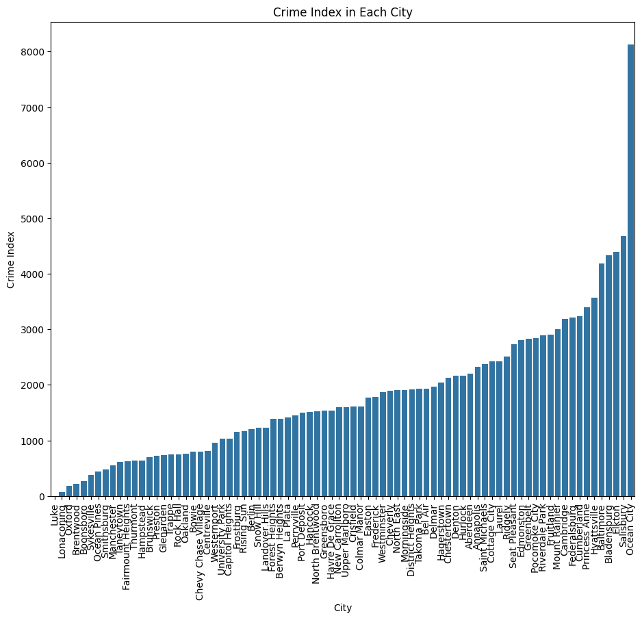

```python
# converting data under crime index column to string and then remove all commas
remove_comma = merged_df['Crime Index ▲'].astype(str).str.replace(',', '')

# converting data in crime index to numerical number
merged_df['Crime Index ▲'] = pd.to_numeric(remove_comma)

# plotting a bar graph for crime index in each city
plt.figure(figsize=(11, 9))
sns.barplot(x='City', y='Crime Index ▲', data=merged_df.sort_values('Crime Index ▲'))
plt.title('Crime Index in Each City')
plt.xlabel('City')
plt.ylabel('Crime Index')
plt.xticks(rotation=90)
plt.show()
```

This graph here shows the number of crimes in each of the cities in Maryland. From this graph we can see that the highest crime city is Ocean city and the lowest is Luke. Some questions that we can think of are why does Ocean City have the highest crime index? What factors can lead to crime index being that high? You might have more questions too but for our project, we will use this graph and combine with the graph in the bottom to show which city is the best fit for you.

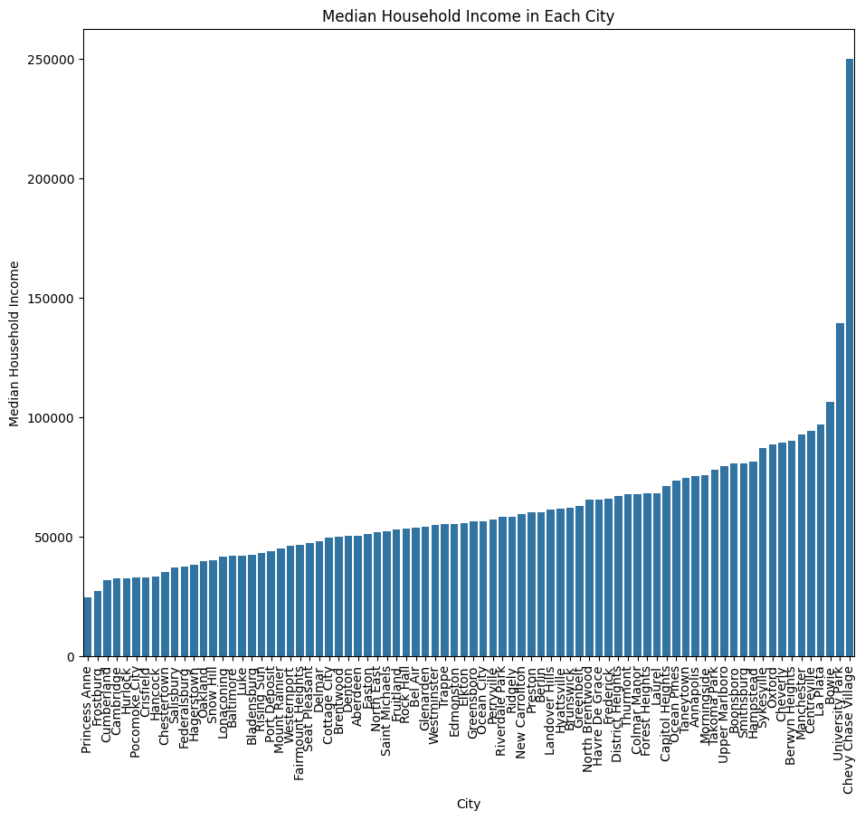

```python
# remove all the commas and dollar signs
remove_comma_dollar = merged_df['Median Household Income'].astype(str).str.replace(',', '').str.replace('$', '')

# converting data to numerical numbers
merged_df['Median Household Income'] = pd.to_numeric(remove_comma_dollar)

# plotting a bar graph for median household income in each city
plt.figure(figsize=(11, 9))
sns.barplot(x='City', y='Median Household Income', data=merged_df.sort_values('Median Household Income'))
plt.title('Median Household Income in Each City')
plt.xlabel('City')
plt.ylabel('Median Household Income')
plt.xticks(rotation=90)
plt.show()
```

This graph shows the median household incomes across various cities in Maryland, allowing viewers to compare income levels between locations. We will next show the graph of the Median House price in each city and comparing it to the median household income.

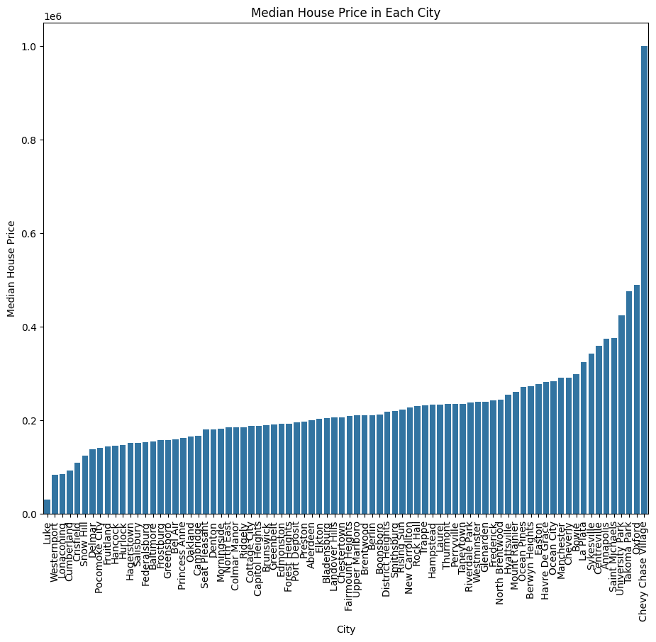

```python
# removing all commas and dollar signs
remove_dollar_comma = merged_df['Median House Price'].astype(str).str.replace(',', '').str.replace('$', '')

# converting all data to numerical numbers
merged_df['Median House Price'] = pd.to_numeric(remove_dollar_comma)

# plotting a bar graph for median house price in each city
plt.figure(figsize=(11, 9))
sns.barplot(x='City', y='Median House Price', data=merged_df.sort_values('Median House Price'))
plt.title('Median House Price in Each City')
plt.xlabel('City')
plt.ylabel('Median House Price')
plt.xticks(rotation=90)
plt.show()
```

This bar graph shows the median house prices in various cities across Maryland and is a very valuable tool for people seeking the perfect place to live in Maryland. By visually comparing the heights of the bars, people can decide a city that has house prices within their budget. Furthermore, looking at this graph and the graph above it can help improve people's decision-making by allowing them to prioritize cities based on their preferences for amenities, services, and overall quality of life by just looking at the average house prices and median income. Some people want to live in a rich city because they are used living in a rich area while others are not.

```python
# standardizing scaler
scaler = StandardScaler()
feature_cols = ['Crime Index ▲', 'Median Household Income', 'Median House Price']
merged_df[feature_cols] = scaler.fit_transform(merged_df[feature_cols])

# calculating scores
scores = (merged_df['Crime Index ▲'] * -1) + (merged_df['Median Household Income'] * 1) + (merged_df['Median House Price'] * 1)

# sorting the cities by score
merged_df['Score'] = scores
top_cities = merged_df.sort_values(by='Score', ascending=False)

# printing the top 10 cities
print(top_cities[['City', 'Score']].head(10))
```

```
                   City      Score
20  Chevy Chase Village  13.802439
23      University Park   4.952906
2                Oxford   4.425725
21          Centreville   3.032380
5            Sykesville   2.970669
19                Bowie   2.933485
8            Manchester   2.596514
50          Takoma Park   2.581763
32             La Plata   2.351018
6           Ocean Pines   1.846599
```

To calculate the best cities for us to live in Maryland, we first standardized the scales of the three factors that we are mainly talking about which is crime rate, household income, and median house price. Standardization ensures that each factor is on the same scale so we can compare them. Next, we assigned weights to each factor based on their importance in determining the best cities. In this case, we assigned a weight of -1 to the crime index because the lower the crime rate, the safer the city is, and a weight of 1 to both median household income and median house price. Then, we computed a score for each city by multiplying each standardized factor by its respective weight and summing them up. This score represents the overall attractiveness of each city based on the selected criteria. At the end, we sort the cities based on their scores in descending order to identify the top 10 cities for us to consider living in Maryland.

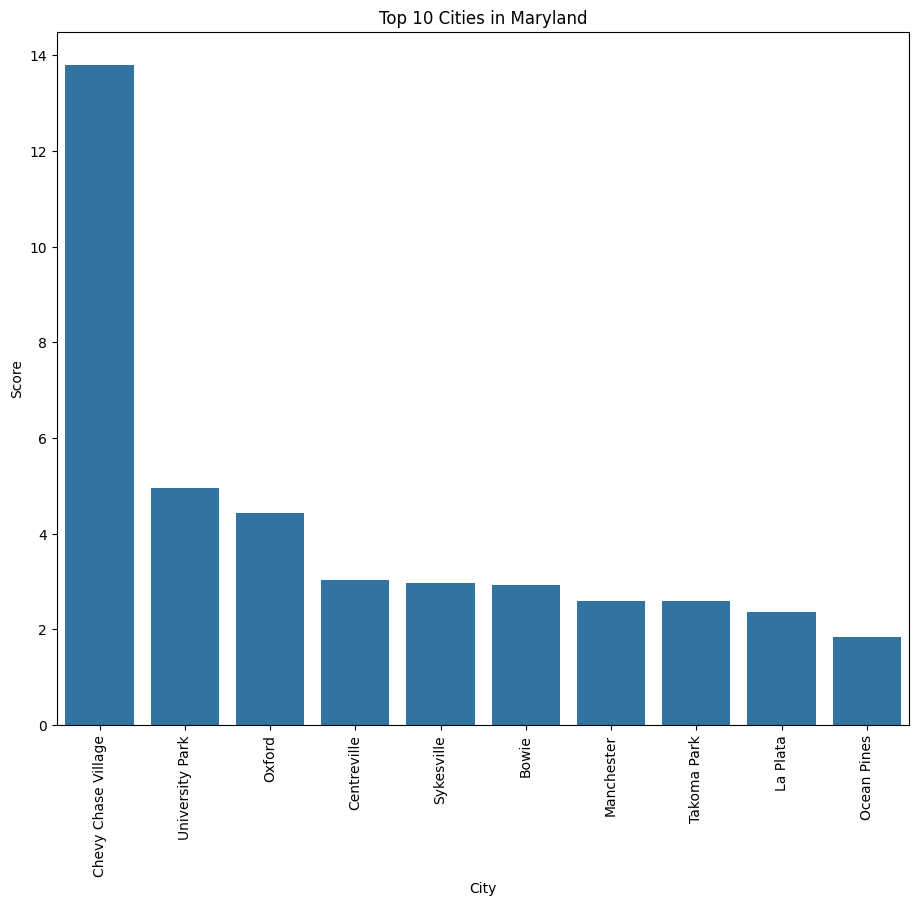

```python
# creating bar plot for the top 10 cities
top_ten = top_cities.head(10)
plt.figure(figsize=(11, 9))
sns.barplot(x='City', y='Score', data=top_ten)
plt.title('Top 10 Cities in Maryland')
plt.xlabel('City')
plt.ylabel('Score')
plt.xticks(rotation=90)
plt.show()
```

```python
# defining incomes
median = merged_df['Median Household Income'].median()
high = merged_df[merged_df['Median Household Income'] > median]
low = merged_df[merged_df['Median Household Income'] <= median]

# performing t-test between high income cities and low income cities
t_test, p_val = stats.ttest_ind(high['Median House Price'], low['Median House Price'])

# printing t-statistic and p-value
print("t-stat: ", t_test)
print("p-val: ", p_val)
```

```
t-stat:  4.139183021992761
p-val:  8.741387629361139e-05
```

## Model: Analysis, Hypothesis Testing, & ML

```python
# removing all unnecessary characters and convert to numerical numbers
df['Crime Index ▲'] = df['Crime Index ▲'].astype(str).str.replace(',', '').astype(int)
df['Population'] = df['Population'].astype(str).str.replace(',', '').astype(int)

# helper function for standardizing the data
def perform_standardization(population, crime_index):
    # setting features and target values
    X, y = population, crime_index

    # perform scaling
    scaler = StandardScaler()
    X_scale = scaler.fit_transform(X)

    # setting training and testing sets data
    X_train, X_test, y_train, y_test = train_test_split(X_scale, y, test_size=0.1, random_state=40)

    # apply linear regression model
    model = LinearRegression()
    model.fit(X_train, y_train)

    # perform perdictions
    y_pred = model.predict(X_test)

    # fitting the model and print a summary of regression results
    constant_X = sm.add_constant(X)
    reg_res = sm.OLS(y, constant_X).fit()
    print(reg_res.summary())

    return mean_squared_error(y_test, y_pred), r2_score(y_test, y_pred), model, X

# using the helper function to get mse and r2 value
mse, r2, model, X = perform_standardization(df[['Population']], df['Crime Index ▲'])

# printing mse and r2 value
print("\nMSE value:", mse)
print("R2 score:", r2)

# getting the coefficient
coef = pd.DataFrame(model.coef_, X.columns, columns=['Coefficient'])
print("\n", coef)
```

```
                            OLS Regression Results
==============================================================================
Dep. Variable:          Crime Index ▲   R-squared:                       0.058
Model:                            OLS   Adj. R-squared:                  0.046
Method:                 Least Squares   F-statistic:                     4.766
Date:                Sat, 11 May 2024   Prob (F-statistic):             0.0320
Time:                        00:14:56   Log-Likelihood:                -683.31
No. Observations:                  80   AIC:                             1371.
Df Residuals:                      78   BIC:                             1375.
Df Model:                           1
Covariance Type:            nonrobust
==============================================================================
                 coef    std err          t      P>|t|      [0.025      0.975]
------------------------------------------------------------------------------
const       1737.4324    144.094     12.058      0.000    1450.563    2024.302
Population     0.0044      0.002      2.183      0.032       0.000       0.008
==============================================================================
Omnibus:                       50.646   Durbin-Watson:                   0.211
Prob(Omnibus):                  0.000   Jarque-Bera (JB):              214.315
Skew:                           1.943   Prob(JB):                     2.90e-47
Kurtosis:                      10.014   Cond. No.                     7.30e+04
==============================================================================

Notes:
[1] Standard Errors assume that the covariance matrix of the errors is correctly specified.
[2] The condition number is large, 7.3e+04. This might indicate that there are
strong multicollinearity or other numerical problems.

MSE value: 209187.1845085706
R2 score: -0.0561542978869638

             Coefficient
Population   303.476217
```

This part can tell us which city in Maryland might be the best fit for you to live in. We start by ensuring that the data, such as population and crime index, is clean and ready for analysis. Then, we focus on population size as a factor to consider. We train a model to see if there's a link between a city's population and its crime rate. By examining metrics like mean squared error and R-squared, we can get an idea of how accurately our model predicts crime based on population size. This analysis helps us understand if there's a connection between the number of people living in a city and its crime levels. Additionally, the code reveals the coefficients, showing us the extent to which population size influences crime rates.

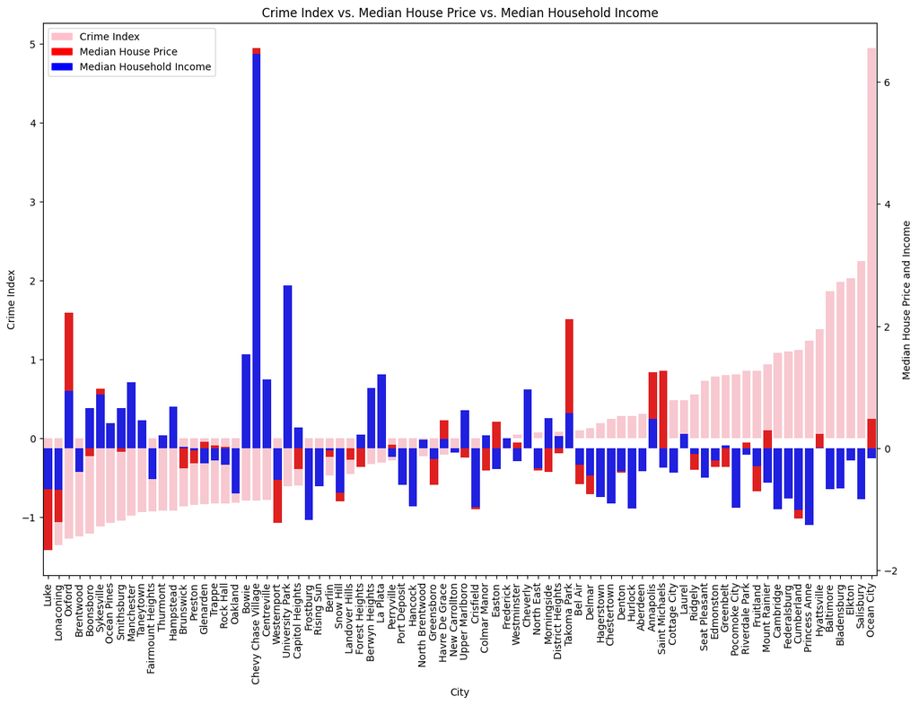

```python
# helper function for plotting crime index axis
def first_axis(axis1):
    sns.barplot(x='City', y='Crime Index ▲', data=merged_df, color='pink', ax=axis1)
    axis1.set_title('Crime Index vs. Median House Price vs. Median Household Income')
    axis1.set_xlabel('City')
    axis1.set_ylabel('Crime Index')
    create_leg1 = mpatches.Patch(color='pink', label='Crime Index')

    return create_leg1

# helper function for plotting median house price and median household income axis
def second_axis(axis2):
    sns.barplot(x='City', y='Median House Price', data=merged_df, color='red', ax=axis2)
    create_leg2 = mpatches.Patch(color='red', label='Median House Price')

    sns.barplot(x='City', y='Median Household Income', data=merged_df, color='blue', ax=axis2)
    create_leg3 = mpatches.Patch(color='blue', label='Median Household Income')

    axis2.set_ylabel('Median House Price and Income')

    return create_leg2, create_leg3

# plotting a bar plot comparing crime index, median house price, and median household income
plt.figure(figsize=(15, 10))
axis1 = plt.gca()
axis2 = axis1.twinx()

# calling helper to create bar plot and return legends at the same time
crime_leg, (house_leg, income_leg) = first_axis(axis1), second_axis(axis2)

# show legends and make the x-axis more readable
axis1.legend(handles=[crime_leg, house_leg, income_leg])
axis1.tick_params(axis='x', labelrotation=90)

plt.show()
```

This graph compares the crime index, median house prices, and median household incomes across various cities, revealing that higher crime indices often correspond to lower house prices and incomes. Some cities maintain high economic indicators despite moderate crime levels, showcasing the different factors that can influence urban economic conditions.

## Conclusion and Future Insights

To review, We've taken a close look at crime rates, household income, and housing prices to better understand Maryland's cities. By analyzing several different data points and using both detailed statistical methods and machine learning, we've started to figure out what makes a city appealing. Our study shows we need to consider more than just population size when looking at crime rates because it's not a very strong predictor on its own. We also found a clear connection between how much people earn and the cost of homes, with big differences sometimes showing up between areas that are close together. If you're thinking about moving or you're into urban planning, these insights could be really useful.

If we wanted to conduct further research, we could potentially increase the area that we were researching and look at other cities. We could also look at other factors that could possibly influence crime rates such as health, education, community, and employment opportunities.

This is just the beginning of what we can discover. Maryland has over 150 cities, each with its own unique mix of economic situations, suggesting there's a lot more to learn. Our research offers a basic roadmap for anyone interested in making these cities better places to live. We hope our work encourages more exploration and smarter decision-making as well as giving you some insight into how you can leverage data

## More Information

If you are interested in living in Maryland, or you are currently living in Maryland, here are some more links related to crime in Maryland and in the United States.

-[CrimeGrade - Safest Places in Maryland City, MD](https://crimegrade.org/safest-places-in-maryland-city-md/)

-[UCR Crime Statistics](https://cde.ucr.cjis.gov/)

Thank you for looking at our project about Cities in Maryland!! We hope you learned a lot of Data Science and more about how to find the best city to live in.